# Kiva Crowdfunding Analysis Project

Author

Shraddha Powar

The Kiva.org dataset provides valuable information related to loans issued over the last two years. It includes details about borrowers, their welfare levels, and other relevant factors. The dataset aims to help Kiva better understand and serve entrepreneurs around the world by assessing borrower welfare levels.

**Data Set Link:** [Data Science for Good: Kiva Crowdfunding](https://www.kaggle.com/datasets/kiva/data-science-for-good-kiva-crowdfunding/data)

# Required Libraries

```r
library(tidyverse)
library(leaflet)
library(knitr)
library(ggplot2)
library(tidyr)
library(tidytext)
library(stringr)
library(DT)
library(treemap)
library(caret)
library(reshape2)
```

# Loading the Data Set

- **Kiva Loans (`kiva_loans.csv`)**: Records of loans made through Kiva, detailing amounts, activities, sectors, use, geographic location, and repayment information.
- **Kiva MPI Region Locations (`kiva_mpi_region_locations.csv`)**: Geographic and MPI (Multidimensional Poverty Index) data for regions where Kiva operates, including location names, ISO codes, countries, and coordinates.
- **Loan Theme IDs (`loan_theme_ids.csv`)**: Matches loan IDs to theme IDs and types, providing insights into the broader purpose or categorization of loans.

```r
folder_name <- 'D:/NUIG BA/MS5130_Applied Analytics_R/R_A3/data/'

# Load data
kiva_loans <- read_csv(file = paste0(folder_name,"kiva_loans.csv"))
kiva_mpi_region_locations <- read_csv(file = paste0(folder_name,"kiva_mpi_region_locations.csv"))
loan_themes <- read_csv(file = paste0(folder_name,"loan_theme_ids.csv"))
```

# Exploratory Data Analysis

## Kiva Loans Data

```r
# To check the data type of each column
str(kiva_loans)
```

```
spc_tbl_ [671,205 × 20] (S3: spec_tbl_df/tbl_df/tbl/data.frame)
 $ id                : num [1:671205] 653051 653053 653068 653063 653084 ...
 $ funded_amount     : num [1:671205] 300 575 150 200 400 250 200 400 475 625 ...
 $ loan_amount       : num [1:671205] 300 575 150 200 400 250 200 400 475 625 ...
 $ activity          : chr [1:671205] "Fruits & Vegetables" "Rickshaw" "Transportation" "Embroidery" ...
 $ sector            : chr [1:671205] "Food" "Transportation" "Transportation" "Arts" ...
 $ use               : chr [1:671205] "To buy seasonal, fresh fruits to sell." "to repair and maintain the auto rickshaw used in their business." "To repair their old cycle-van and buy another one to rent out as a source of income" "to purchase an embroidery machine and a variety of new embroidery m…
 $ country_code      : chr [1:671205] "PK" "PK" "IN" "PK" ...
 $ country           : chr [1:671205] "Pakistan" "Pakistan" "India" "Pakistan" ...
 $ region            : chr [1:671205] "Lahore" "Lahore" "Maynaguri" "Lahore" ...
 $ currency          : chr [1:671205] "PKR" "PKR" "INR" "PKR" ...
 $ partner_id        : num [1:671205] 247 247 334 247 245 NA 334 245 245 247 ...
 $ posted_time       : POSIXct[1:671205], format: "2014-01-01 06:12:39" "2014-01-01 06:51:08" ...
 $ disbursed_time    : POSIXct[1:671205], format: "2013-12-17 08:00:00" "2013-12-17 08:00:00" ...
 $ funded_time       : POSIXct[1:671205], format: "2014-01-02 10:06:32" "2014-01-02 09:17:23" ...
 $ term_in_months    : num [1:671205] 12 11 43 11 14 4 43 14 14 11 ...
 $ lender_count      : num [1:671205] 12 14 6 8 16 6 8 8 19 24 ...
 $ tags              : chr [1:671205] NA NA "user_favorite, user_favorite" NA ...
 $ borrower_genders  : chr [1:671205] "female" "female, female" "female" "female" ...
 $ repayment_interval: chr [1:671205] "irregular" "irregular" "bullet" "irregular" ...
 $ date              : Date[1:671205], format: "2014-01-01" "2014-01-01" ...
 - attr(*, "spec")=
  .. cols(
  ..   id = col_double(),
  ..   funded_amount = col_double(),
  ..   loan_amount = col_double(),
  ..   activity = col_character(),
  ..   sector = col_character(),
  ..   use = col_character(),
  ..   country_code = col_character(),
  ..   country = col_character(),
  ..   region = col_character(),
  ..   currency = col_character(),
  ..   partner_id = col_double(),
  ..   posted_time = col_datetime(format = ""),
  ..   disbursed_time = col_datetime(format = ""),
  ..   funded_time = col_datetime(format = ""),
  ..   term_in_months = col_double(),
  ..   lender_count = col_double(),
  ..   tags = col_character(),
  ..   borrower_genders = col_character(),
  ..   repayment_interval = col_character(),
  ..   date = col_date(format = "")
  .. )
 - attr(*, "problems")=<externalptr>
```

```r
# To view the data snippet
kable(head(kiva_loans,3))
```

| id | funded_amount | loan_amount | activity | sector | use | country_code | country | region | currency | partner_id | posted_time | disbursed_time | funded_time | term_in_months | lender_count | tags | borrower_genders | repayment_interval | date |
| --- | --- | --- | --- | --- | --- | --- | --- | --- | --- | --- | --- | --- | --- | --- | --- | --- | --- | --- | --- |
| 653051 | 300 | 300 | Fruits & Vegetables | Food | To buy seasonal, fresh fruits to sell. | PK | Pakistan | Lahore | PKR | 247 | 2014-01-01 06:12:39 | 2013-12-17 08:00:00 | 2014-01-02 10:06:32 | 12 | 12 | NA | female | irregular | 2014-01-01 |
| 653053 | 575 | 575 | Rickshaw | Transportation | to repair and maintain the auto rickshaw used in their business. | PK | Pakistan | Lahore | PKR | 247 | 2014-01-01 06:51:08 | 2013-12-17 08:00:00 | 2014-01-02 09:17:23 | 11 | 14 | NA | female, female | irregular | 2014-01-01 |
| 653068 | 150 | 150 | Transportation | Transportation | To repair their old cycle-van and buy another one to rent out as a source of income | IN | India | Maynaguri | INR | 334 | 2014-01-01 09:58:07 | 2013-12-17 08:00:00 | 2014-01-01 16:01:36 | 43 | 6 | user_favorite, user_favorite | female | bullet | 2014-01-01 |

```r
#To get the shape of data
dim(kiva_loans)
```

```
[1] 671205     20
```

### Loan Amount Distribution

The loan amount is shown in the form of a histogram. The X axis has been log transformed for better visualization.

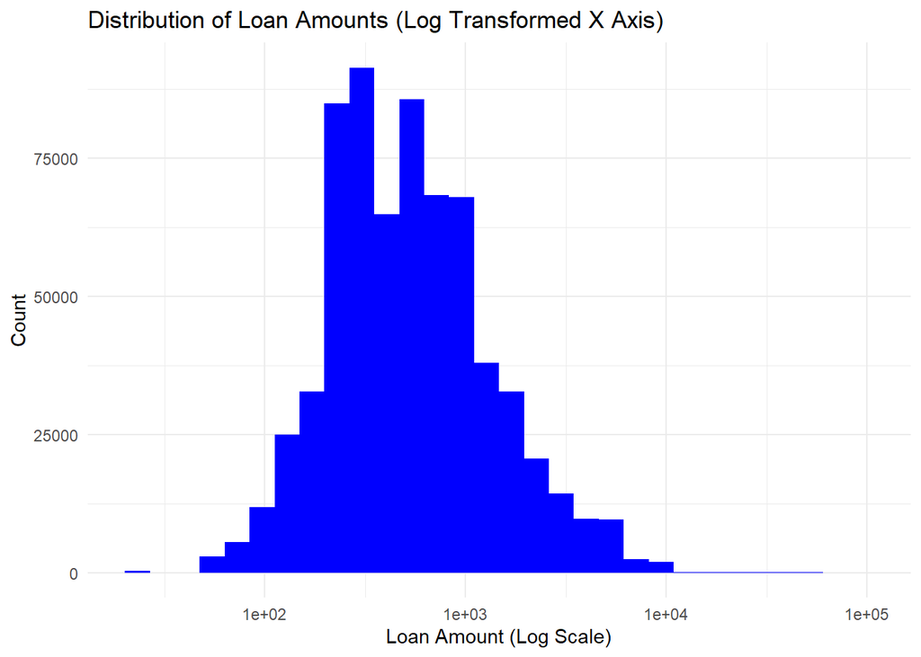

```r
ggplot(kiva_loans, aes(x = loan_amount)) +
  geom_histogram(fill = "blue", bins = 30) +
  scale_x_log10() +  # Apply log transformation to the x-axis
  labs(title = "Distribution of Loan Amounts (Log Transformed X Axis)",
       x = "Loan Amount (Log Scale)",
       y = "Count") +
  theme_minimal()
```

### Distribution of Loans by Gender

```r
head(unique(kiva_loans$borrower_genders))
```

```
[1] "female"
[2] "female, female"
[3] "female, female, female"
[4] "female, female, female, female, female, female, female, female"
[5] "male"
[6] "male, male, male, male, male"
```

```r
kiva_loans <- kiva_loans %>%
  mutate(borrower_genders = ifelse(str_detect(borrower_genders, "female"), "female", "male"))
```

```r
unique(kiva_loans$borrower_genders)
```

```
[1] "female" "male"   NA
```

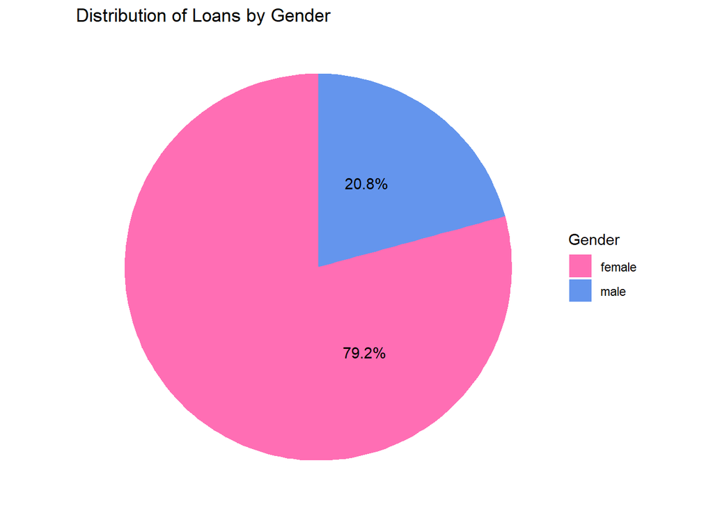

```r
kiva_loans %>%
  filter(!is.na(borrower_genders)) %>%
  count(borrower_genders) %>%
  mutate(percent = n / sum(n) * 100) %>%
  ggplot(aes(x = "", y = n, fill = borrower_genders)) +
  geom_col() +
  coord_polar(theta = "y") + # Transform the bar plot into a pie chart
  scale_fill_manual(values = c("female" = "hotpink1", "male" = "cornflowerblue")) +
  geom_text(aes(label = paste0(round(percent, 1), "%"), y = n / 2),
            position = position_stack(vjust = 0.8)) +
  labs(title = "Distribution of Loans by Gender", fill = "Gender") +
  theme_void()
```

Females loan more than males.

### Loans by Country and Sector

#### Top Countries by Number of Loans

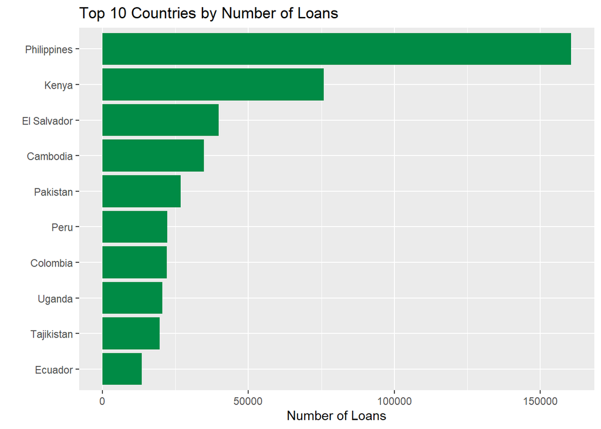

```r
kiva_loans %>%
  group_by(country) %>%
  summarise(Count = n()) %>%
  top_n(10) %>%
  ggplot(aes(x = reorder(country, Count), y = Count)) +
  geom_bar(stat = "identity", fill = "springgreen4") +
  coord_flip() +
  labs(title = "Top 10 Countries by Number of Loans", x = "", y = "Number of Loans")
```

Phillipines, Kenya & El Salvador are most popular countries for loans whom Kiva has funded.

#### Loans by Sector

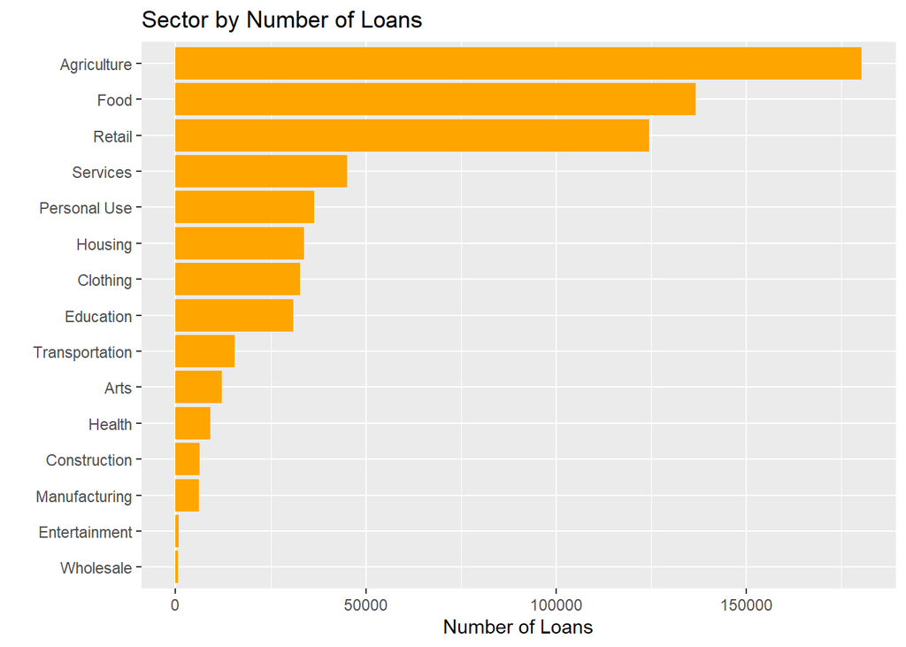

```r
kiva_loans %>%
  group_by(sector) %>%
  summarise(Count = n()) %>%
  ggplot(aes(x = reorder(sector, Count), y = Count)) +
  geom_bar(stat = "identity", fill = "orange") +
  coord_flip() +
  labs(title = "Sector by Number of Loans", x = "", y = "Number of Loans")
```

Agriculture, Food and Retail are the most common sectors for which customers take loans.

### Use of Loans

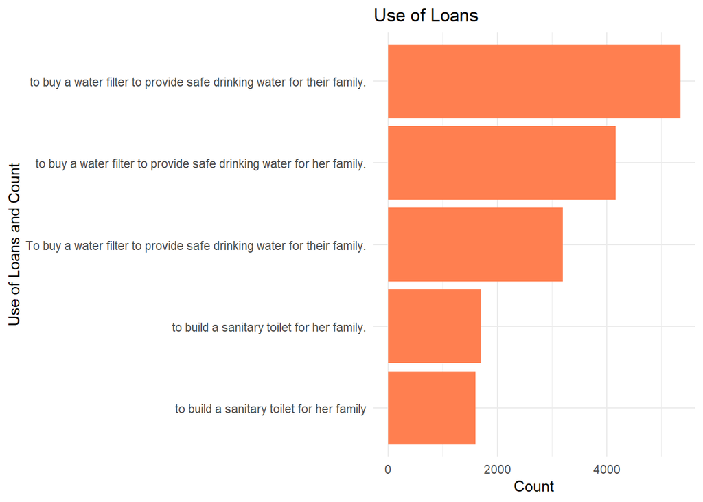

```r
kiva_loans %>%
  mutate(use = trimws(use)) %>%
  filter(!is.na(use)) %>%
  group_by(use) %>%
  summarise(Count = n()) %>%
  arrange(desc(Count)) %>%
  ungroup() %>%
  mutate(use = reorder(use,Count)) %>%
  head(5) %>%

  ggplot(aes(x = use,y = Count)) +
  geom_bar(stat='identity', fill = "coral") +
  labs(x = 'Use of Loans and Count',
       y = 'Count',
       title = 'Use of Loans') +
     coord_flip()+
  theme_minimal()
```

Unclear Information. We need to remove common words and trim the `use` column to extract meaningful information from it.

## Textual Analysis

To explore words most associated with education and agriculture sector.

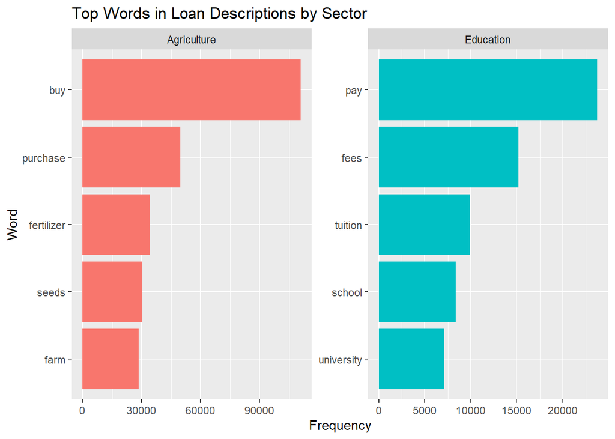

```r
kiva_loans %>%
  filter(grepl("agriculture|education", sector, ignore.case = TRUE)) %>%
  unnest_tokens(word, use) %>%
  anti_join(stop_words) %>%
  count(sector, word, sort = TRUE) %>%
  group_by(sector) %>%
  top_n(5) %>%
  ungroup() %>%
  ggplot(aes(x = reorder(word, n), y = n, fill = sector)) +
  geom_col(show.legend = FALSE) +
  facet_wrap(~sector, scales = "free") +
  coord_flip() +
  labs(x = "Word", y = "Frequency", title = "Top Words in Loan Descriptions by Sector")
```

- Helps in identifying Sector-Specific needs. For example, in agriculture, words like “buy,” “fertilizer,” and “seeds” suggest that loans are often sought for purchasing supplies. This insight can help Kiva to tailor their support programs to the specific need of that sector.

## Kiva MPI Region Locations

```r
# To check the data type of each column
str(kiva_mpi_region_locations)
```

```
spc_tbl_ [2,772 × 9] (S3: spec_tbl_df/tbl_df/tbl/data.frame)
 $ LocationName: chr [1:2772] "Badakhshan, Afghanistan" "Badghis, Afghanistan" "Baghlan, Afghanistan" "Balkh, Afghanistan" ...
 $ ISO         : chr [1:2772] "AFG" "AFG" "AFG" "AFG" ...
 $ country     : chr [1:2772] "Afghanistan" "Afghanistan" "Afghanistan" "Afghanistan" ...
 $ region      : chr [1:2772] "Badakhshan" "Badghis" "Baghlan" "Balkh" ...
 $ world_region: chr [1:2772] "South Asia" "South Asia" "South Asia" "South Asia" ...
 $ MPI         : num [1:2772] 0.387 0.466 0.3 0.301 0.325 0.313 0.319 0.25 0.245 0.384 ...
 $ geo         : chr [1:2772] "(36.7347725, 70.81199529999999)" "(35.1671339, 63.7695384)" "(35.8042947, 69.2877535)" "(36.7550603, 66.8975372)" ...
 $ lat         : num [1:2772] 36.7 35.2 35.8 36.8 34.8 ...
 $ lon         : num [1:2772] 70.8 63.8 69.3 66.9 67.8 ...
 - attr(*, "spec")=
  .. cols(
  ..   LocationName = col_character(),
  ..   ISO = col_character(),
  ..   country = col_character(),
  ..   region = col_character(),
  ..   world_region = col_character(),
  ..   MPI = col_double(),
  ..   geo = col_character(),
  ..   lat = col_double(),
  ..   lon = col_double()
  .. )
 - attr(*, "problems")=<externalptr>
```

```r
# To view the data snippet
kable(head(kiva_mpi_region_locations,3))
```

| LocationName | ISO | country | region | world_region | MPI | geo | lat | lon |
| --- | --- | --- | --- | --- | --- | --- | --- | --- |
| Badakhshan, Afghanistan | AFG | Afghanistan | Badakhshan | South Asia | 0.387 | (36.7347725, 70.81199529999999) | 36.73477 | 70.81200 |
| Badghis, Afghanistan | AFG | Afghanistan | Badghis | South Asia | 0.466 | (35.1671339, 63.7695384) | 35.16713 | 63.76954 |
| Baghlan, Afghanistan | AFG | Afghanistan | Baghlan | South Asia | 0.300 | (35.8042947, 69.2877535) | 35.80429 | 69.28775 |

```r
#To get the shape of data
dim(kiva_mpi_region_locations)
```

```
[1] 2772    9
```

### Multidimensional Poverty Index (MPI) Map

References:

1. Learning leaflet: https://geanders.github.io/navy_public_health/4-3-leaflet.html
2. For choosing the layer: https://leaflet-extras.github.io/leaflet-providers/preview/

```r
color_scheme <- colorNumeric(
  palette = colorRampPalette(c('green', 'red'))(length(kiva_mpi_region_locations$MPI)),
  domain = kiva_mpi_region_locations$MPI)

regions_no_NA = kiva_mpi_region_locations %>%
  filter(!is.na(lon)) %>%
  filter(!is.na(lat))

leaflet(data = regions_no_NA) %>%
  addTiles() %>%
  addCircleMarkers(
    lng =  ~ lon,
    lat =  ~ lat,
    radius = ~ MPI*10,
    popup =  ~ country,
    color =  ~ color_scheme(MPI)
  ) %>%
  addProviderTiles(providers$CartoDB.Positron) %>%
  addLegend("topleft", pal = color_scheme, values = ~MPI,
          title = "MPI Map",
           opacity = 1)
```

[interactive chart not shown]

Higher the MPI, poorer is the country. The map clearly shows the poorer countries are centered around Africa.The **Red Dots** indicate that the country is poorer.

### Merge `kiva_mpi_region_locations` with `kiva_loans` data

```r
merged_data <- kiva_loans %>%
  left_join(kiva_mpi_region_locations, by = c("country" = "country", "region" = "region"))
```

### Explore Merged Data

```r
# To check the data type of each column
str(merged_data)
```

```
tibble [671,205 × 27] (S3: tbl_df/tbl/data.frame)
 $ id                : num [1:671205] 653051 653053 653068 653063 653084 ...
 $ funded_amount     : num [1:671205] 300 575 150 200 400 250 200 400 475 625 ...
 $ loan_amount       : num [1:671205] 300 575 150 200 400 250 200 400 475 625 ...
 $ activity          : chr [1:671205] "Fruits & Vegetables" "Rickshaw" "Transportation" "Embroidery" ...
 $ sector            : chr [1:671205] "Food" "Transportation" "Transportation" "Arts" ...
 $ use               : chr [1:671205] "To buy seasonal, fresh fruits to sell." "to repair and maintain the auto rickshaw used in their business." "To repair their old cycle-van and buy another one to rent out as a source of income" "to purchase an embroidery machine and a variety of new embroidery m…
 $ country_code      : chr [1:671205] "PK" "PK" "IN" "PK" ...
 $ country           : chr [1:671205] "Pakistan" "Pakistan" "India" "Pakistan" ...
 $ region            : chr [1:671205] "Lahore" "Lahore" "Maynaguri" "Lahore" ...
 $ currency          : chr [1:671205] "PKR" "PKR" "INR" "PKR" ...
 $ partner_id        : num [1:671205] 247 247 334 247 245 NA 334 245 245 247 ...
 $ posted_time       : POSIXct[1:671205], format: "2014-01-01 06:12:39" "2014-01-01 06:51:08" ...
 $ disbursed_time    : POSIXct[1:671205], format: "2013-12-17 08:00:00" "2013-12-17 08:00:00" ...
 $ funded_time       : POSIXct[1:671205], format: "2014-01-02 10:06:32" "2014-01-02 09:17:23" ...
 $ term_in_months    : num [1:671205] 12 11 43 11 14 4 43 14 14 11 ...
 $ lender_count      : num [1:671205] 12 14 6 8 16 6 8 8 19 24 ...
 $ tags              : chr [1:671205] NA NA "user_favorite, user_favorite" NA ...
 $ borrower_genders  : chr [1:671205] "female" "female" "female" "female" ...
 $ repayment_interval: chr [1:671205] "irregular" "irregular" "bullet" "irregular" ...
 $ date              : Date[1:671205], format: "2014-01-01" "2014-01-01" ...
 $ LocationName      : chr [1:671205] NA NA NA NA ...
 $ ISO               : chr [1:671205] NA NA NA NA ...
 $ world_region      : chr [1:671205] NA NA NA NA ...
 $ MPI               : num [1:671205] NA NA NA NA NA NA NA NA NA NA ...
 $ geo               : chr [1:671205] NA NA NA NA ...
 $ lat               : num [1:671205] NA NA NA NA NA NA NA NA NA NA ...
 $ lon               : num [1:671205] NA NA NA NA NA NA NA NA NA NA ...
```

```r
# To view the data snippet
kable(head(merged_data,3))
```

| id | funded_amount | loan_amount | activity | sector | use | country_code | country | region | currency | partner_id | posted_time | disbursed_time | funded_time | term_in_months | lender_count | tags | borrower_genders | repayment_interval | date | LocationName | ISO | world_region | MPI | geo | lat | lon |
| --- | --- | --- | --- | --- | --- | --- | --- | --- | --- | --- | --- | --- | --- | --- | --- | --- | --- | --- | --- | --- | --- | --- | --- | --- | --- | --- |
| 653051 | 300 | 300 | Fruits & Vegetables | Food | To buy seasonal, fresh fruits to sell. | PK | Pakistan | Lahore | PKR | 247 | 2014-01-01 06:12:39 | 2013-12-17 08:00:00 | 2014-01-02 10:06:32 | 12 | 12 | NA | female | irregular | 2014-01-01 | NA | NA | NA | NA | NA | NA | NA |
| 653053 | 575 | 575 | Rickshaw | Transportation | to repair and maintain the auto rickshaw used in their business. | PK | Pakistan | Lahore | PKR | 247 | 2014-01-01 06:51:08 | 2013-12-17 08:00:00 | 2014-01-02 09:17:23 | 11 | 14 | NA | female | irregular | 2014-01-01 | NA | NA | NA | NA | NA | NA | NA |
| 653068 | 150 | 150 | Transportation | Transportation | To repair their old cycle-van and buy another one to rent out as a source of income | IN | India | Maynaguri | INR | 334 | 2014-01-01 09:58:07 | 2013-12-17 08:00:00 | 2014-01-01 16:01:36 | 43 | 6 | user_favorite, user_favorite | female | bullet | 2014-01-01 | NA | NA | NA | NA | NA | NA | NA |

```r
dim(merged_data)
```

```
[1] 671205     27
```

### Distribution of Funded Loan Amount By Country

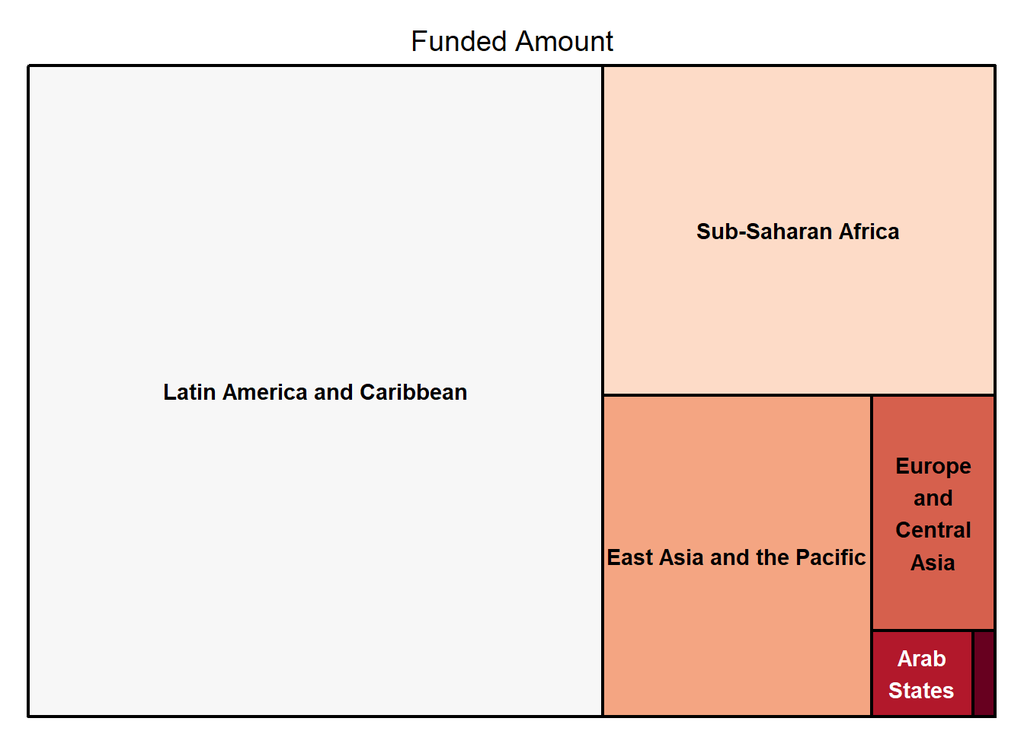

```r
loans_funded_amount = merged_data %>%
  group_by(world_region) %>%
  summarise(FundedAmount = sum(funded_amount)) %>%
  arrange(desc(FundedAmount)) %>%
  ungroup() %>%
  mutate(world_region = reorder(world_region,FundedAmount)) %>%



treemap(loans_funded_amount,
        index="world_region",
        vSize = "FundedAmount",
        title="Funded Amount",
        palette = "RdBu"
)
```

More than 50% of total loans funded by Kiva are in Latin America and Caribbean Region. This is followed by Sub-Saharan Africa and East Asia.

### Relation between Loan Amount and Multidimensional Poverty Index

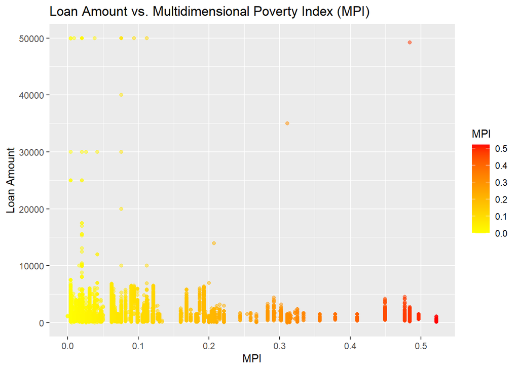

```r
data <- merged_data %>%
  filter(!is.na(MPI))

ggplot(data, aes(x = MPI, y = loan_amount)) +
  geom_point(aes(color = MPI), alpha = 0.5) +
  scale_color_gradient(low = "yellow", high = "red") +
  labs(title = "Loan Amount vs. Multidimensional Poverty Index (MPI)", x = "MPI", y = "Loan Amount")
```

Loan amounts tend to be higher in areas with very low Multidimensional Poverty Index (MPI) values, indicating a correlation between lower poverty levels and the ability to secure larger loans.

Conversely, in regions where the MPI is higher, reflecting greater poverty, the loan amounts accessed are significantly lower.

This pattern suggests that the extent of poverty, as measured by the MPI, may influence the scale of financial assistance provided or sought through loans.

# Kiva’s Impact

[Kiva.org](https://www.kaggle.com/kiva) is an online crowd funding platform to extend financial services to poor and financially excluded people around the world.

So the data of interest for KIVA are countries with high Multidimensional Poverty Index

## Filter merged_data

where MPI > 80th Percentile

```r
mpi_quartiles <- quantile(merged_data$MPI, probs = c(0.80), na.rm = TRUE)

high_mpi_data <- merged_data %>%
  filter(MPI >= mpi_quartiles[1])
```

## Locations With High MPI

```r
high_mpi_region <- high_mpi_data %>%
  select(world_region,country,region,MPI) %>%
  distinct() %>%
  arrange(desc(MPI))
datatable(high_mpi_region, options = list(pageLength = 10, autoWidth = TRUE),
          filter = 'top', class = 'cell-border stripe')
```

|  | world_region | country | region | MPI |
| --- | --- | --- | --- | --- |
| 1 | Sub-Saharan Africa | Sierra Leone | Port Loko | 0.522 |
| 2 | East Asia and the Pacific | Timor-Leste | Ermera | 0.4970000000000001 |
| 3 | Sub-Saharan Africa | Mali | Sikasso | 0.484 |
| 4 | Sub-Saharan Africa | Sierra Leone | Kenema | 0.477 |
| 5 | Sub-Saharan Africa | Sierra Leone | Bo | 0.449 |
| 6 | East Asia and the Pacific | Timor-Leste | Viqueque | 0.41 |
| 7 | East Asia and the Pacific | Timor-Leste | Aileu | 0.379 |
| 8 | East Asia and the Pacific | Timor-Leste | Baucau | 0.357 |
| 9 | Sub-Saharan Africa | Malawi | Salima | 0.334 |
| 10 | Arab States | Yemen | Dhamar | 0.325 |

[output cut: 5 more lines]

## High MPI Location by Funded Amount

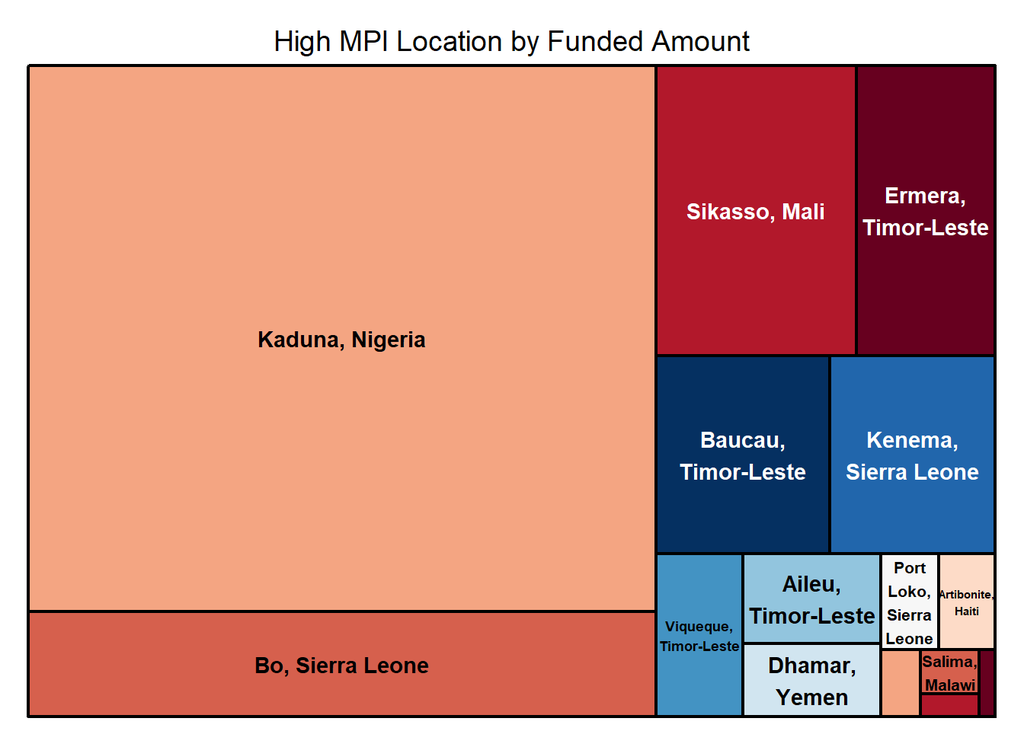

```r
high_mpi_funded_amount = high_mpi_data %>%
  group_by(LocationName) %>%
  summarise(FundedAmount = sum(funded_amount)) %>%
  arrange(desc(FundedAmount)) %>%
  ungroup() %>%
  mutate(LocationName = reorder(LocationName,FundedAmount)) %>%

treemap(loans_funded_amount,
        index="LocationName",
        vSize = "FundedAmount",
        title="High MPI Location by Funded Amount",
        palette = "RdBu"
)
```

This helps assess the to monitor the allocation of resources for Kiva in poverty allveation efforts

## Loan Themes

```r
# To check the data type of each column
str(loan_themes)
```

```
spc_tbl_ [779,092 × 4] (S3: spec_tbl_df/tbl_df/tbl/data.frame)
 $ id             : num [1:779092] 638631 640322 641006 641019 641594 ...
 $ Loan Theme ID  : chr [1:779092] "a1050000000skGl" "a1050000000skGl" "a1050000002X1ij" "a1050000002X1ij" ...
 $ Loan Theme Type: chr [1:779092] "General" "General" "Higher Education" "Higher Education" ...
 $ Partner ID     : num [1:779092] 151 151 160 160 336 217 57 217 133 48 ...
 - attr(*, "spec")=
  .. cols(
  ..   id = col_double(),
  ..   `Loan Theme ID` = col_character(),
  ..   `Loan Theme Type` = col_character(),
  ..   `Partner ID` = col_double()
  .. )
 - attr(*, "problems")=<externalptr>
```

```r
# To view the data snippet
kable(head(loan_themes,3))
```

| id | Loan Theme ID | Loan Theme Type | Partner ID |
| --- | --- | --- | --- |
| 638631 | a1050000000skGl | General | 151 |
| 640322 | a1050000000skGl | General | 151 |
| 641006 | a1050000002X1ij | Higher Education | 160 |

```r
dim(loan_themes)
```

```
[1] 779092      4
```

## Merge `loan_themes` with `high_MPI_data`

```r
high_mpi_data_wt_themes <- high_mpi_data %>%
  left_join(loan_themes, by = "id")
```

## Top 5 Loan Themes in High MPI Regions

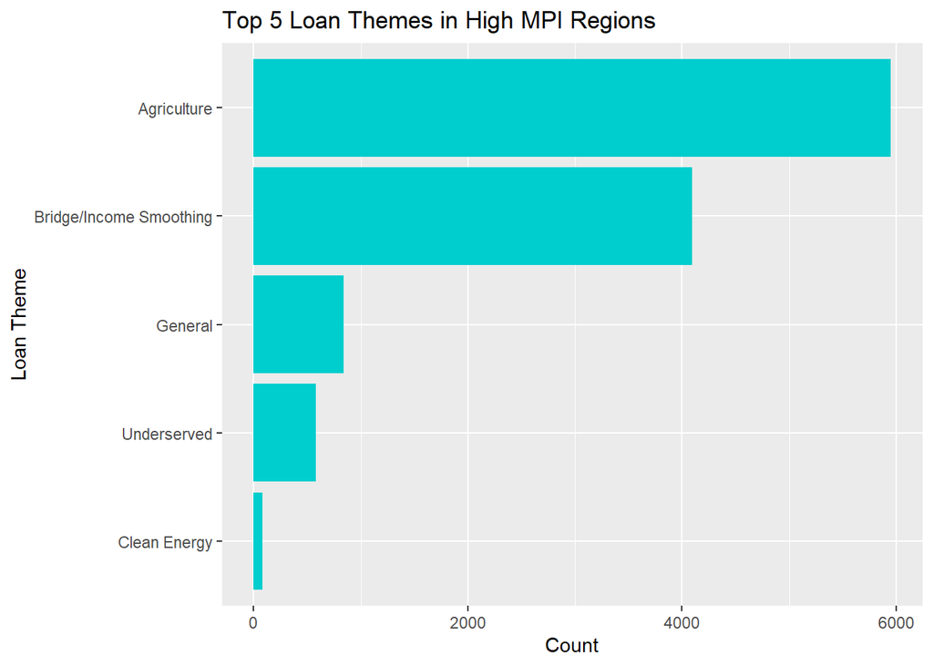

```r
high_mpi_data_wt_themes %>%
  filter(!is.na(`Loan Theme Type`)) %>%
  group_by(`Loan Theme Type`) %>%
  summarise(Count = n()) %>%
  top_n(5) %>%
  ggplot(aes(x = reorder(`Loan Theme Type`, Count), y = Count)) +
  geom_bar(stat = "identity", fill = "cyan3") +
  coord_flip() +
  labs(title = "Top 5 Loan Themes in High MPI Regions", x = "Loan Theme", y = "Count")
```

# Quantitative Analysis

Model to Predict Loan Amount By sector, LocationName & MPI

```r
merged_data$sector <- as.factor(merged_data$sector)
merged_data$LocationName <- as.factor(merged_data$LocationName)

merged_data <- merged_data[complete.cases(merged_data),]

# Split data into training and testing sets
set.seed(123)
index <- createDataPartition(merged_data$loan_amount, p=0.8, list=FALSE)
trainData <- merged_data[index, ]
testData <- merged_data[-index, ]

# Build the linear regression model
model <- lm(loan_amount ~ sector + MPI + LocationName, data=trainData)

# Summarize the model
summary(model)
```

```
Call:
lm(formula = loan_amount ~ sector + MPI + LocationName, data = trainData)

Residuals:
   Min     1Q Median     3Q    Max
 -4073   -281    -86    120  48974

Coefficients: (1 not defined because of singularities)
                                       Estimate Std. Error t value Pr(>|t|)
(Intercept)                             -70.582   3038.532  -0.023 0.981468
sectorArts                             -390.062     70.748  -5.513 3.55e-08 ***
sectorClothing                          -61.735     44.799  -1.378 0.168200
sectorConstruction                     -159.227     94.746  -1.681 0.092860 .
sectorEducation                         -41.440     39.346  -1.053 0.292245
sectorEntertainment                      85.571    282.926   0.302 0.762310
sectorFood                                7.855     35.905   0.219 0.826821
sectorHealth                           -335.363     89.903  -3.730 0.000192 ***
sectorHousing                           -57.815     41.324  -1.399 0.161807
sectorManufacturing                     322.145    111.199   2.897 0.003770 **
sectorPersonal Use                     -282.658     33.606  -8.411  < 2e-16 ***
sectorRetail                             23.440     38.140   0.615 0.538843
sectorServices                         -168.748     50.677  -3.330 0.000870 ***
sectorTransportation                   -159.331     88.259  -1.805 0.071044 .
sectorWholesale                        1479.249    235.040   6.294 3.15e-10 ***
MPI                                   13731.089  48516.550   0.283 0.777165
LocationNameAhuachapan, El Salvador    1458.650   1700.086   0.858 0.390908
LocationNameAileu, Timor-Leste        -4180.808  15354.106  -0.272 0.785399
LocationNameArequipa, Peru             1076.407   2604.090   0.413 0.679352
LocationNameArtibonite, Haiti         -3511.686  12299.211  -0.286 0.775247
LocationNameAyacucho, Peru              -36.498    456.381  -0.080 0.936260
LocationNameBalaka, Malawi            -2273.575  10697.473  -0.213 0.831692
LocationNameBali, Indonesia            3224.714   1026.236   3.142 0.001678 **
LocationNameBamako, Mali               -235.947   5117.551  -0.046 0.963227
LocationNameBaucau, Timor-Leste       -3838.302  14285.737  -0.269 0.788177
LocationNameBo, Sierra Leone          -4851.498  18748.879  -0.259 0.795821
LocationNameBoaco, Nicaragua          -1082.830   3274.602  -0.331 0.740892
LocationNameCajamarca, Peru            -368.151   1512.166  -0.243 0.807651
LocationNameCallao, Peru               1660.645   3334.871   0.498 0.618514
LocationNameChikwawa, Malawi          -2375.564  11133.343  -0.213 0.831037
LocationNameChimaltenango, Guatemala   1858.265    986.220   1.884 0.059544 .
```

[output cut: 81 more lines]

```
LocationNameTaiz, Yemen               -1746.672   7008.657  -0.249 0.803195
LocationNameTakeo, Cambodia            -923.101   2109.819  -0.438 0.661733
LocationNameThimphu, Bhutan           10240.947   2647.763   3.868 0.000110 ***
LocationNameThyolo, Malawi            -2557.022   9550.614  -0.268 0.788906
LocationNameTotonicapan, Guatemala     3111.390   2844.243   1.094 0.273997
LocationNameUcayali, Peru               106.906    875.442   0.122 0.902808
LocationNameUlaanbaatar, Mongolia      1842.683   2748.260   0.670 0.502551
LocationNameViqueque, Timor-Leste     -4644.594  16857.744  -0.276 0.782921
LocationNameYoro, Honduras                   NA         NA      NA       NA
---
Signif. codes:  0 '***' 0.001 '**' 0.01 '*' 0.05 '.' 0.1 ' ' 1

Residual standard error: 1373 on 27767 degrees of freedom
Multiple R-squared:  0.197, Adjusted R-squared:  0.1935
F-statistic: 57.23 on 119 and 27767 DF,  p-value: < 2.2e-16
```

```r
# Predictions
predictions <- predict(model, newdata=testData)

# Measure performance
MAE <- mean(abs(predictions - testData$loan_amount))
print(paste("Mean Absolute Error:", MAE))
```

```
[1] "Mean Absolute Error: 421.770753416557"
```

A Mean Absolute Error (MAE) of approximately 422 suggests that on average, the predictions of our model deviate from the actual values by about 422.

```r
merged_data %>%
  select(loan_amount) %>%
  summary()
```

```
  loan_amount
 Min.   :   25.0
 1st Qu.:  200.0
 Median :  500.0
 Mean   :  818.8
 3rd Qu.: 1000.0
 Max.   :50000.0
```

The target variable `loan_amount` ranges between 25 and 50000 where the median is 500, an MAE of 422 suggest that the model is not performing well and there is scope for improvement

# Mermaid Flowchart Representation

```
 flowchart LR

 kiva_loans --> EDA1[Exploratory Data Analysis]
 kiva_loans --> TA[Textual Analysis: sector specific needs]
 kiva_loans --> M1[merge 1: merged_data]

 kiva_mpi_region_locations --> T[identify high mpi locations]
 kiva_mpi_region_locations --> M1

 M1 --> FILTER[filter MPI > 80th Percentile : high_mpi_data]
 M1 --> QA[Quantitative Analysis: predict loan amount]

 FILTER --> M2[merge 2: high_mpi_data_wt_themes]
 loan_themes --> M2
 M2 --> T5[identify top 5 loan themes ]
```

# Conclusion

To conclude, the objective of this project analysis was to enhance Kiva’s insight into global welfare disparities. By examining the allocation of funds across high MPI locations, we have aimed to provide Kiva with a detailed understanding of where their resources can be most effectively utilized to improve borrower welfare and support poverty alleviation efforts worldwide.